# Quick tour of R Markdown

Anaga and Aaron

2025-04-15

# R Markdown

- Already installed in all R Studio (File > New File > R Markdown)
- R Markdown makes it easier for scientists (you) to write code and free-text at the same time
- Code is organized into **“chunks”**
- R Markdown files can be used to create (called **“knit”**) files in HTML, PDF, Word, Powerpoint, and more
- R Markdown is compatible with Github and traditional R language as well as Python, Bash, SQL, and more
- If your end product is a report of statistics, Markdown can be particularly useful to automate making a report

# Why use R Markdown?

From Hadley Wickham:

1. For communicating to decision makers, who want to focus on the conclusions, not the code behind the analysis.
2. For collaborating with other data scientists (including future you!), who are interested in both your conclusions, and how you reached them (i.e., the code).
3. As an environment in which to **do** data science, as a modern day lab notebook where you can capture not only what you did, but also what you were thinking.

Source: https://r4ds.had.co.nz/r-markdown.html

# Some examples!

1. Finished products: with the package kable, for nice packages: https://github.com/aaron-maruzzo/R-group/blob/main/summary_table.html
2. To demo to other data scientists: https://cran.r-project.org/web/packages/ggplot2/vignettes/ggplot2.html
3. As a lab notebook: https://rpubs.com/MaisAlraee/1297517

# Let’s download knitr

```r
#install.packages("knitr")
library(knitr)
```

# In-line expressions

With Markdown you can write sentences that reference elements of your data analysis.

For example, let’s say we wanted to describe the chicken weights dataset. How many chickens are there?

```r
data(chickwts)
head(chickwts, n=10)
```

```
##    weight      feed
## 1     179 horsebean
## 2     160 horsebean
## 3     136 horsebean
## 4     227 horsebean
## 5     217 horsebean
## 6     168 horsebean
## 7     108 horsebean
## 8     124 horsebean
## 9     143 horsebean
## 10    140 horsebean
```

```r
nrow(chickwts)
```

```
## [1] 71
```

In-line expressions are written as ` r `.

For example, these render the same in the final output (this slide) but the code looks different:

- “There were 71 chickens” (the explicit approach)
- “There were 71 chickens” (the in-line approach)

In-line expressions can also be helpful to create sentences that may change over time.

Consider the following sentences:

- The mean weight of the chickens was 261.31 grams.

```r
levels(chickwts$feed)
```

```
## [1] "casein"    "horsebean" "linseed"   "meatmeal"  "soybean"   "sunflower"
```

```r
mod <- summary(lm(weight ~ feed, data=chickwts))
mod
```

```
##
## Call:
## lm(formula = weight ~ feed, data = chickwts)
##
## Residuals:
##      Min       1Q   Median       3Q      Max
## -123.909  -34.413    1.571   38.170  103.091
##
## Coefficients:
##               Estimate Std. Error t value Pr(>|t|)
## (Intercept)    323.583     15.834  20.436  < 2e-16 ***
## feedhorsebean -163.383     23.485  -6.957 2.07e-09 ***
## feedlinseed   -104.833     22.393  -4.682 1.49e-05 ***
## feedmeatmeal   -46.674     22.896  -2.039 0.045567 *
## feedsoybean    -77.155     21.578  -3.576 0.000665 ***
## feedsunflower    5.333     22.393   0.238 0.812495
## ---
## Signif. codes:  0 '***' 0.001 '**' 0.01 '*' 0.05 '.' 0.1 ' ' 1
##
## Residual standard error: 54.85 on 65 degrees of freedom
## Multiple R-squared:  0.5417, Adjusted R-squared:  0.5064
## F-statistic: 15.36 on 5 and 65 DF,  p-value: 5.936e-10
```

- Horsebean feed is significantly associated with an average decrease of -163.38 grams compared to casein feed.

# Contingency tables

If you’re creating many, many two-way tables and want an efficient way of creating a report that contains your tables, Markdown is very helpful.

```r
chickwts$dead <- sample(c(0,1), size=nrow(chickwts), replace = T)
chickwts$color <- sample(c("blue", "green", "red"), size=nrow(chickwts), replace=T)
chickwts$eyecolor <- sample(c("yellow", "orange", "purple"), size=nrow(chickwts), replace=T)

# chicken mortality by feed and color
table(chickwts$dead, chickwts$feed, chickwts$color)
```

```
## , ,  = blue
##
##
##     casein horsebean linseed meatmeal soybean sunflower
##   0      2         1       2        5       4         4
##   1      0         1       1        0       1         1
##
## , ,  = green
##
##
##     casein horsebean linseed meatmeal soybean sunflower
##   0      2         5       0        0       1         4
##   1      1         1       5        2       3         2
##
## , ,  = red
##
##
##     casein horsebean linseed meatmeal soybean sunflower
##   0      3         1       2        2       5         1
##   1      4         1       2        2       0         0
```

```r
# chicken mortality by feed and eye color
table(chickwts$dead, chickwts$feed, chickwts$eyecolor)
```

```
## , ,  = orange
##
##
##     casein horsebean linseed meatmeal soybean sunflower
##   0      3         2       1        2       3         2
##   1      1         1       1        0       2         0
##
## , ,  = purple
##
##
##     casein horsebean linseed meatmeal soybean sunflower
##   0      0         2       2        1       4         3
##   1      4         0       4        2       1         1
##
## , ,  = yellow
##
##
##     casein horsebean linseed meatmeal soybean sunflower
##   0      4         3       1        4       3         4
##   1      0         2       3        2       1         2
```

# Pretty tables

Helpful libraries:

- gtsummary
- kable (@Anaga’s table!)
- kableExtra
- flextable

```r
# example using gtsummary

# install.packages("gtsummary")
library(gtsummary)
chickwts %>%
  tbl_strata(
    strata = color,
    .tbl_fun =
      ~ .x %>%
      tbl_summary(by = dead, include = feed),
    .header = "**{strata}**, N = {n}"
  )
```

| **Characteristic** | **blue**, N = 22 **0**, N = 18<sup>1</sup> | **blue**, N = 22 **1**, N = 4<sup>1</sup> | **green**, N = 26 **0**, N = 12<sup>1</sup> | **green**, N = 26 **1**, N = 14<sup>1</sup> | **red**, N = 23 **0**, N = 14<sup>1</sup> | **red**, N = 23 **1**, N = 9<sup>1</sup> |
| --- | --- | --- | --- | --- | --- | --- |
| feed |  |  |  |  |  |  |
| casein | 2 (11%) | 0 (0%) | 2 (17%) | 1 (7.1%) | 3 (21%) | 4 (44%) |
| horsebean | 1 (5.6%) | 1 (25%) | 5 (42%) | 1 (7.1%) | 1 (7.1%) | 1 (11%) |
| linseed | 2 (11%) | 1 (25%) | 0 (0%) | 5 (36%) | 2 (14%) | 2 (22%) |
| meatmeal | 5 (28%) | 0 (0%) | 0 (0%) | 2 (14%) | 2 (14%) | 2 (22%) |
| soybean | 4 (22%) | 1 (25%) | 1 (8.3%) | 3 (21%) | 5 (36%) | 0 (0%) |
| sunflower | 4 (22%) | 1 (25%) | 4 (33%) | 2 (14%) | 1 (7.1%) | 0 (0%) |

<sup>1</sup> n (%)

# Tips and tricks to get started with Markdown

**Cheat Sheet and Reference Guide** for R Markdown available with Help > Cheatsheets

- You can toggle between “Source” and “Visual” to preview your script as an HTML product (can help review your own work). The source-visual toggle is located below the save button.
- You can use hashtags to create headers/sections. Open Outline (on the upper right hand side) and navigate your own document by section.
- Each chunk comes with a play button (to run the chunk), play all prior chunks, and a settings button. The settings allow you to customize your code chunks and the chunk’s results. ~60 options available.
  - See the full list here: http://yihui.name/knitr/options/.
  - For example, **echo**=F prevents the code, but not the results, from appearing in the finished file (echo=T when you want to show the code)
  - You can also customize when to hide warnings (**warning**=F) or hide messages (**message**=F). Useful when loading packages.
- As long as you have datasets in your working environment (right), you can use Markdown alongside traditional R scripts. Try using **source()** at the top of your Markdown file, and writing comments from your analysis in Markdown.

# Plots

You can also include plots in Markdown. You may still need to adjust the size of your plots according to your output file.

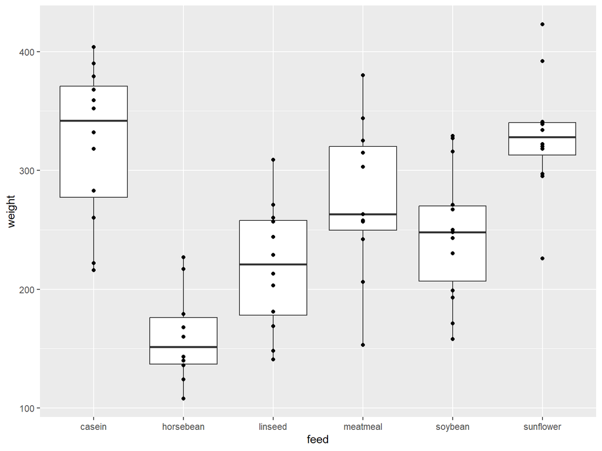

```r
# note- this chunk has warning=F and message=F to hide the messages from uploading these packages!
library(ggplot2)
library(tidyverse)
chickwts %>%
  ggplot(aes(x = feed, y = weight)) +
  geom_boxplot() +
  geom_point()
```

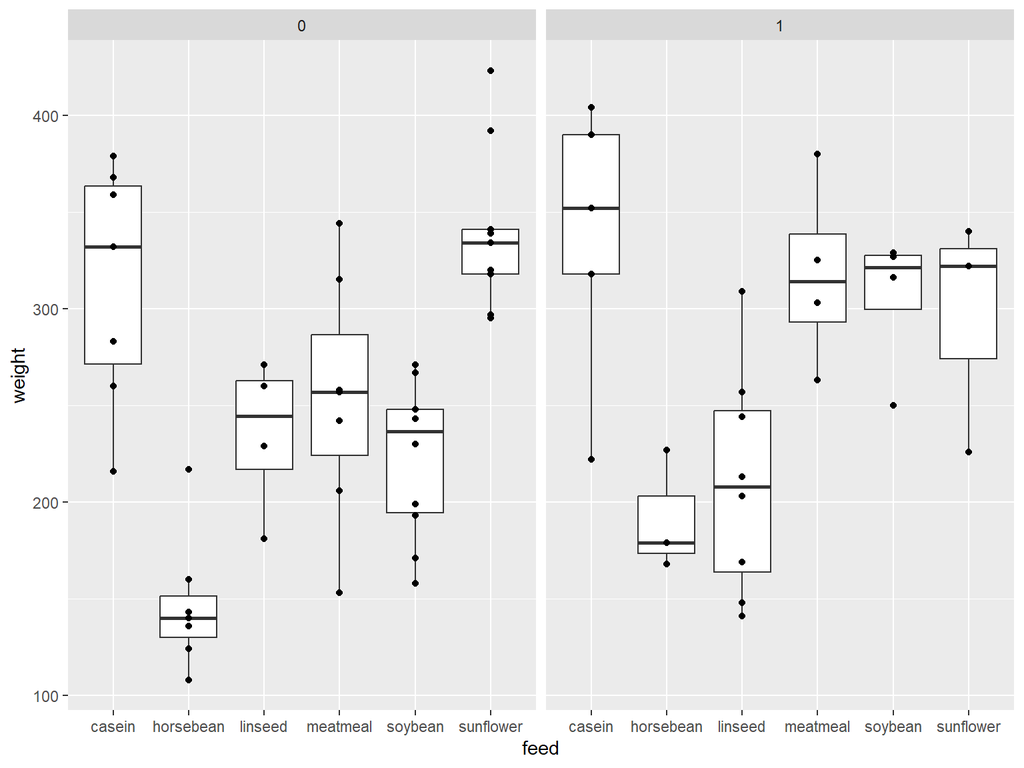

```r
chickwts %>%
  ggplot(aes(x = feed, y = weight)) +
  geom_boxplot() +
  geom_point() +
  facet_wrap(~dead)
```

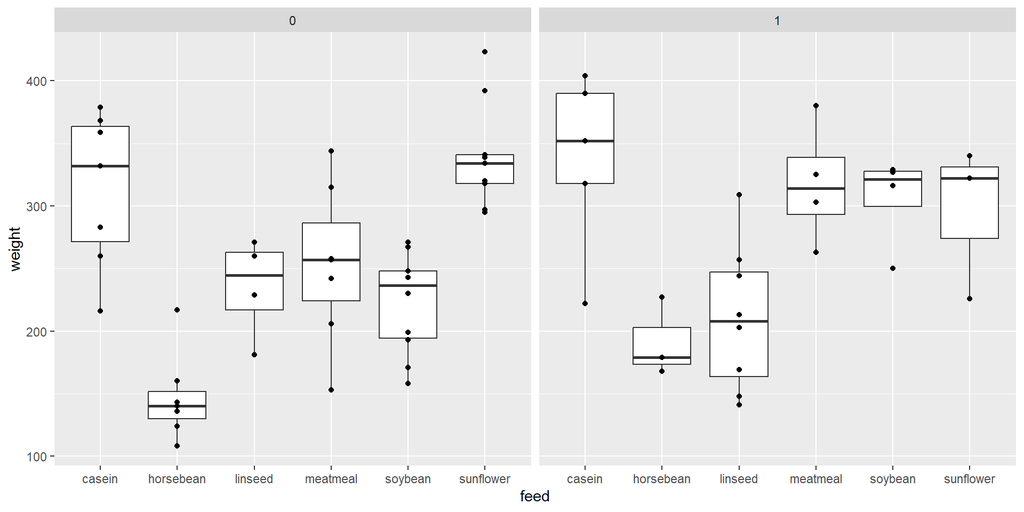

```r
# set fig.width=10, fig.height=5
# defaults to 7 inches
chickwts %>%
  ggplot(aes(x = feed, y = weight)) +
  geom_boxplot() +
  geom_point() +
  facet_wrap(~dead)
```

# YouTube videos and other helpful resources

- Hadley Wickham’s Markdown introduction (**recommended**): https://r4ds.had.co.nz/r-markdown.html
- Video on getting started with Markdown: https://www.youtube.com/watch?v=DNS7i2m4sB0
- Video on getting started with Markdown: https://www.youtube.com/watch?v=asHhuHRxhvo
- RStudio’s R Markdown introduction: https://rmarkdown.rstudio.com/index.html

# Activity

Your turn! Use Markdown to write about the regressions we started last week! You’ll already have read in the data and should have graphs you can format in an R markdown file.

Here’s the folder path: C:Spring Dropbox\1. Central_Filesand data management\2025-04-04 building a regression model

Try at least one:

1. Create a PDF report with section headers.

Hint: Look at this (https://r4ds.had.co.nz/r-markdown.html) and change html to pdf

2. Use an in-line expression.

Reminder: ` r blahblahblah `

3. Create a few different tables and plots, and a brief description as text.

Hint: Write something like this to start a chunk: ``` {r chickwts-tables, echo=T or F} blahblahblah ```